# R Notebook

[figure not shown]

# Graphs

Let me show you a graph (from wikipedia):

[figure not shown]

As you can see, it is simply a representation of two sets:

1. A set of **vertices** or **nodes**. In the image above you see the nodes *1*, *2*, *3*, *4*, *5*, and *6*.
2. A set of **edges** or **links**. In the image above, the links are connecting pairs of nodes.

Altogether, a *graph* reveals some *relationship* among the *nodes*. The graph structure will allow us to explore and understand that relationship.

## Creating Graphs

The graph above can be represented computationally in R using **igraph**:

```r
library(igraph)
G = graph_from_edgelist(matrix( c(1, 2, 1, 5,2,5,2,3,3,4,4,5,4,6),
                                ncol = 2,
                                byrow = TRUE),
                        directed = FALSE)
```

## Basic Elements

**G** is the graph:

```r
#basic info:
G
```

```
## IGRAPH f6cf968 U--- 6 7 --
## + edges from f6cf968:
## [1] 1--2 1--5 2--5 2--3 3--4 4--5 4--6
```

```r
# You see nodes

V(G)
```

```
## + 6/6 vertices, from f6cf968:
## [1] 1 2 3 4 5 6
```

```r
# You see edges
E(G)
```

```
## + 7/7 edges from f6cf968:
## [1] 1--2 1--5 2--5 2--3 3--4 4--5 4--6
```

## Drawing

As you can see, the graph is created by adding pairs of nodes. Once you complete that stage, you can draw the graph:

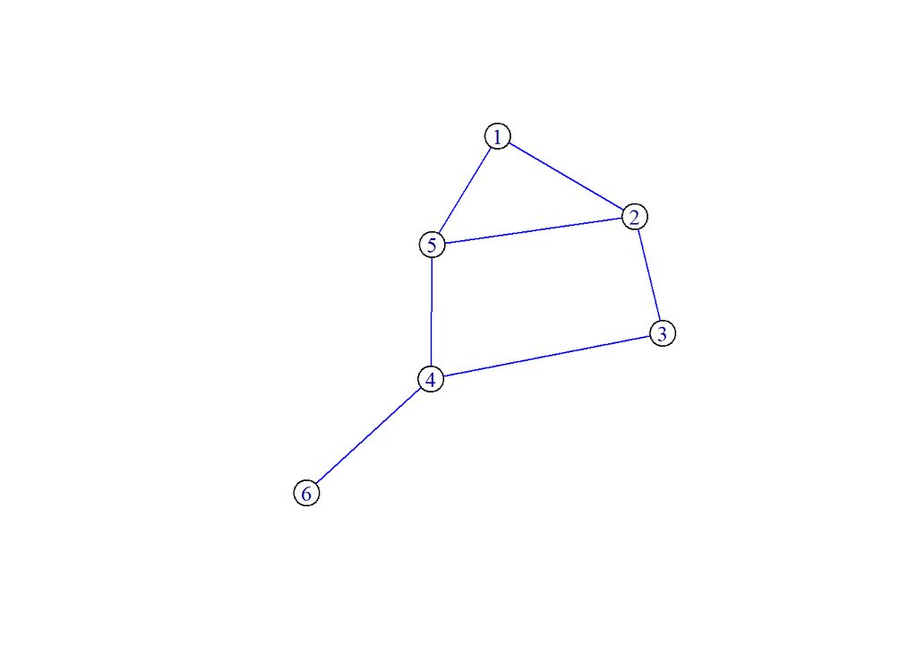

```r
# draw
V(G)$color='white'
E(G)$color='blue'
plot(G)
```

Notice that the position of the nodes will vary every time you re draw the graph. In fact, drawing a graph can become a challenge by itself when we need to find information via visualization.

### Edge directionality

The graph we created and drew represented an **undirected** graph, that is, the relationships between a pair of nodes are **symmetric**: the relationships can not represent direction because they are *inherently mutual* between the nodes. For example, the relationship *to be a neighbor of* is symmetric.

The following graph is **directed**:

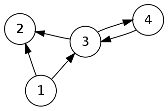

You can create this directed graph just by changing one parameter:

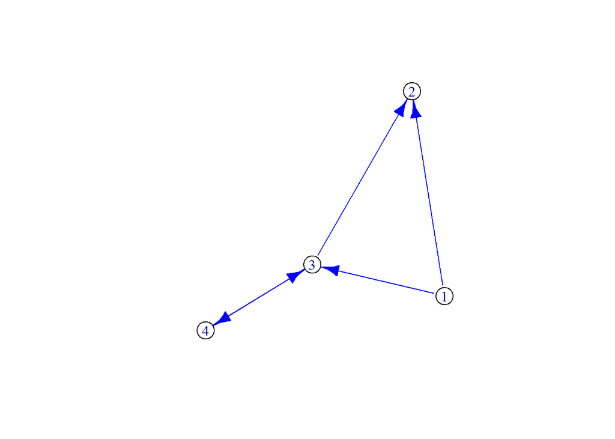

```r
dG = graph_from_edgelist(matrix( c(1, 2, 1, 3,3,2,3,4,4,3),
                                ncol = 2,
                                byrow = TRUE),
                        directed = TRUE)



# drawing
V(dG)$color='white'
E(dG)$color='blue'
plot(dG)
```

Directed links are also called **arcs**. Notice the *Directed graph* created represents an **asymmetric** relationship: the relationship a node has with another node does not need to be mutual, but could be (see nodes *3* and *4*). If the arcs represent **cares for someone**, it shows that the feeling is not reciprocal for most cases in this graph. If a relationship is not mutual, and can only be in one direction, it is called **anti symmetric**.

## Attributes

Nodes can have attributes:

```r
# adding attributes
V(dG)$sex=c('male','male','female','female')
```

```r
# seeing attributes
V(dG)$sex
```

```
## [1] "male"   "male"   "female" "female"
```

Attributes can serve for some computational purposes, but also help to visually find structures.

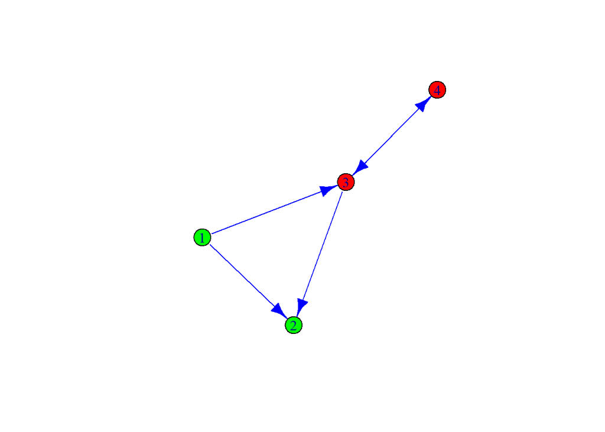

```r
# using node attributes
# Generate colors based on media type:
colorsSex <- c("red", "green")
V(dG)$color <- colorsSex[as.factor(V(dG)$sex)]
plot(dG)
```

Of course, edges can have attributes too:

```r
E(dG)$weight=c(1,3,5,10,2)
```

```r
# see them
E(dG)$weight
```

```
## [1]  1  3  5 10  2
```

Let’s use edge attributes:

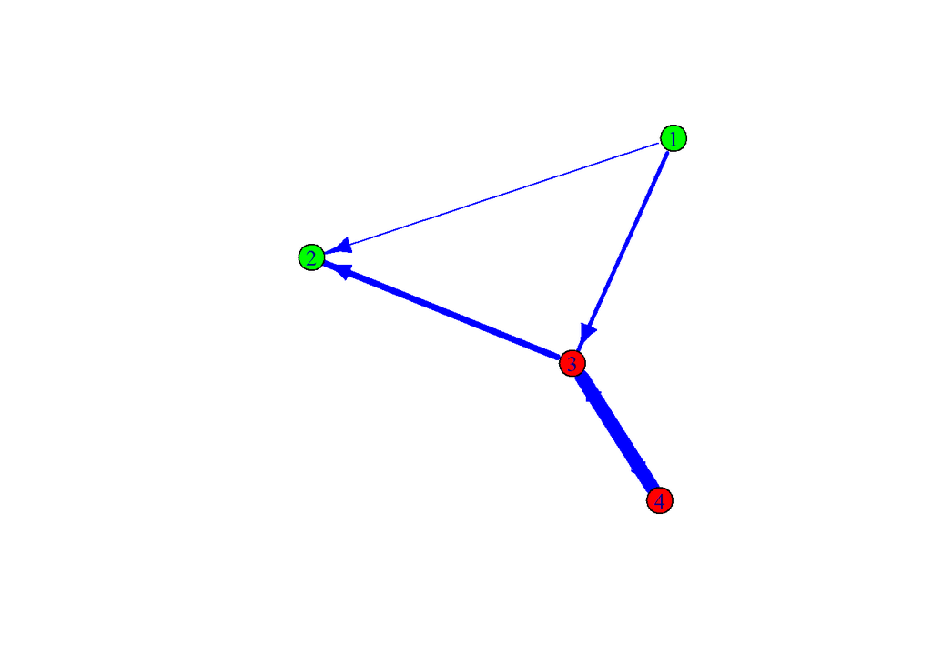

```r
plot(dG,edge.width=E(dG)$weight)
```

## Exporting

You may want to export your graph to be visualized in Gephi or something similar:

```r
where=file.path('data',"dG_R.graphml")
write_graph(dg,where, "graphml")
```

# Case: Elites in Peru

The network we are going to build is based on the relationships studied in this paper:

[figure not shown]

In that paper, Professor Figueroa shows this table, where 1 represents that both nodes (families) appear together at least once in a top company board. Notice the last column is an attribute:

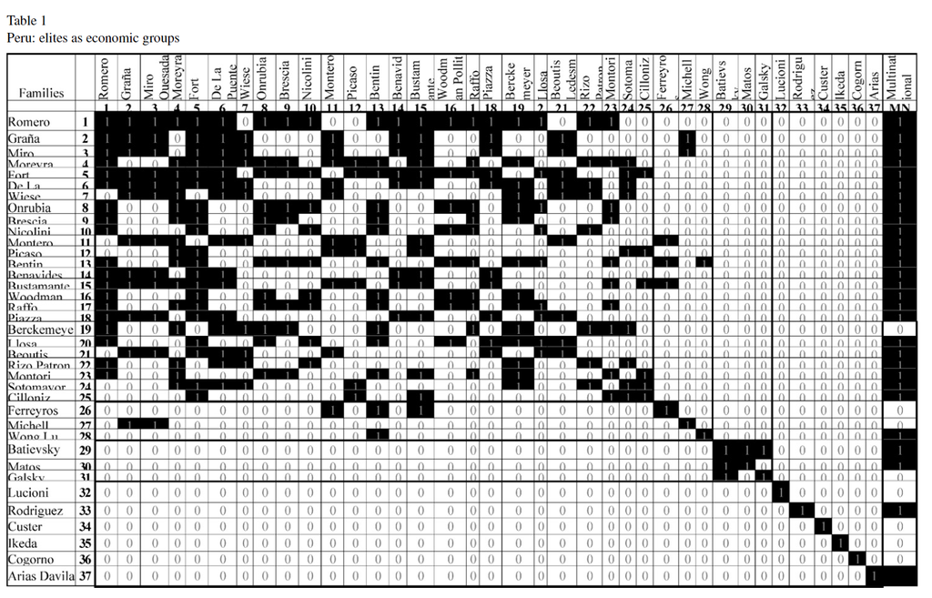

This is an spreadsheet, representing the information above:

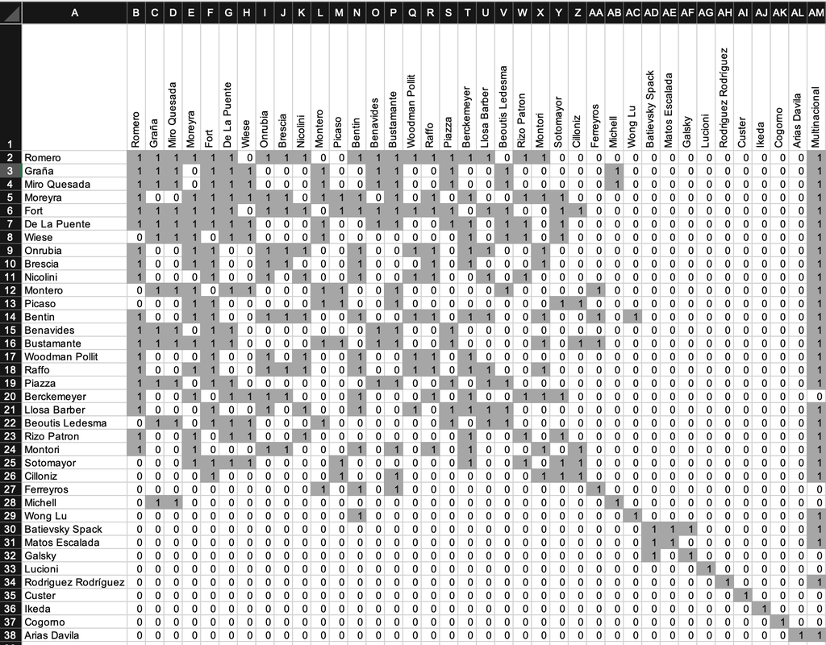

Let’s use the data from the spreadsheet to prepare our table:

```r
library(rio)

file=file.path('data','dataFigueroa.xlsx')

FigueData=import(file)
```

We got this:

```r
head(FigueData)
```

|  | ...1 | Romero | Graña | Miro Quesada | Moreyra | Fort | De La Puente | Wiese | Onrubia | Brescia | Nicolini | Montero | Picaso | Bentin | Benavides | Bustamante | Woodman Pollit | Raffo | Piazza | Berckemeyer | Llosa Barber | Beoutis Ledesma | Rizo Patron | Montori | Sotomayor | Cilloniz | Ferreyros | Michell | Wong Lu | … |
| --- | --- | --- | --- | --- | --- | --- | --- | --- | --- | --- | --- | --- | --- | --- | --- | --- | --- | --- | --- | --- | --- | --- | --- | --- | --- | --- | --- | --- | --- | --- |
| 1 | Romero | 1 | 1 | 1 | 1 | 1 | 1 | 0 | 1 | 1 | 1 | 0 | 0 | 1 | 1 | 1 | 1 | 1 | 1 | 1 | 1 | 0 | 1 | 1 | 0 | 0 | 0 | 0 | 0 | … |
| 2 | Graña | 1 | 1 | 1 | 0 | 1 | 1 | 1 | 0 | 0 | 0 | 1 | 0 | 0 | 1 | 1 | 0 | 0 | 1 | 0 | 0 | 1 | 0 | 0 | 0 | 0 | 0 | 1 | 0 | … |
| 3 | Miro Quesada | 1 | 1 | 1 | 0 | 1 | 1 | 1 | 0 | 0 | 0 | 1 | 0 | 0 | 1 | 1 | 0 | 0 | 1 | 0 | 0 | 1 | 0 | 0 | 0 | 0 | 0 | 1 | 0 | … |
| 4 | Moreyra | 1 | 0 | 0 | 1 | 1 | 1 | 1 | 1 | 1 | 0 | 1 | 1 | 1 | 0 | 1 | 0 | 1 | 0 | 1 | 0 | 0 | 1 | 1 | 1 | 0 | 0 | 0 | 0 | … |
| 5 | Fort | 1 | 1 | 1 | 1 | 1 | 1 | 0 | 1 | 1 | 1 | 0 | 1 | 1 | 1 | 1 | 1 | 1 | 1 | 0 | 1 | 1 | 0 | 0 | 1 | 1 | 0 | 0 | 0 | … |
| 6 | De La Puente | 1 | 1 | 1 | 1 | 1 | 1 | 1 | 0 | 0 | 0 | 1 | 0 | 0 | 1 | 1 | 0 | 0 | 1 | 1 | 0 | 1 | 1 | 0 | 1 | 0 | 0 | 0 | 0 | … |

```r
names(FigueData)
```

```
##  [1] "...1"                "Romero"              "Graña"
##  [4] "Miro Quesada"        "Moreyra"             "Fort"
##  [7] "De La Puente"        "Wiese"               "Onrubia"
## [10] "Brescia"             "Nicolini"            "Montero"
## [13] "Picaso"              "Bentin"              "Benavides"
## [16] "Bustamante"          "Woodman Pollit"      "Raffo"
## [19] "Piazza"              "Berckemeyer"         "Llosa Barber"
## [22] "Beoutis Ledesma"     "Rizo Patron"         "Montori"
## [25] "Sotomayor"           "Cilloniz"            "Ferreyros"
## [28] "Michell"             "Wong Lu"             "Batievsky Spack"
## [31] "Matos Escalada"      "Galsky"              "Lucioni"
## [34] "Rodriguez Rodríguez" "Custer"              "Ikeda"
## [37] "Cogorno"             "Arias Davila"        "Multinacional"
```

```r
row.names(FigueData)=FigueData[,1]
FigueData[,1]=NULL
head(FigueData)
```

|  | Romero | Graña | Miro Quesada | Moreyra | Fort | De La Puente | Wiese | Onrubia | Brescia | Nicolini | Montero | Picaso | Bentin | Benavides | Bustamante | Woodman Pollit | Raffo | Piazza | Berckemeyer | Llosa Barber | Beoutis Ledesma | Rizo Patron | Montori | Sotomayor | Cilloniz | Ferreyros | Michell | Wong Lu | Batievsky Spack | … |
| --- | --- | --- | --- | --- | --- | --- | --- | --- | --- | --- | --- | --- | --- | --- | --- | --- | --- | --- | --- | --- | --- | --- | --- | --- | --- | --- | --- | --- | --- | --- |
| Romero | 1 | 1 | 1 | 1 | 1 | 1 | 0 | 1 | 1 | 1 | 0 | 0 | 1 | 1 | 1 | 1 | 1 | 1 | 1 | 1 | 0 | 1 | 1 | 0 | 0 | 0 | 0 | 0 | 0 | … |
| Graña | 1 | 1 | 1 | 0 | 1 | 1 | 1 | 0 | 0 | 0 | 1 | 0 | 0 | 1 | 1 | 0 | 0 | 1 | 0 | 0 | 1 | 0 | 0 | 0 | 0 | 0 | 1 | 0 | 0 | … |
| Miro Quesada | 1 | 1 | 1 | 0 | 1 | 1 | 1 | 0 | 0 | 0 | 1 | 0 | 0 | 1 | 1 | 0 | 0 | 1 | 0 | 0 | 1 | 0 | 0 | 0 | 0 | 0 | 1 | 0 | 0 | … |
| Moreyra | 1 | 0 | 0 | 1 | 1 | 1 | 1 | 1 | 1 | 0 | 1 | 1 | 1 | 0 | 1 | 0 | 1 | 0 | 1 | 0 | 0 | 1 | 1 | 1 | 0 | 0 | 0 | 0 | 0 | … |
| Fort | 1 | 1 | 1 | 1 | 1 | 1 | 0 | 1 | 1 | 1 | 0 | 1 | 1 | 1 | 1 | 1 | 1 | 1 | 0 | 1 | 1 | 0 | 0 | 1 | 1 | 0 | 0 | 0 | 0 | … |
| De La Puente | 1 | 1 | 1 | 1 | 1 | 1 | 1 | 0 | 0 | 0 | 1 | 0 | 0 | 1 | 1 | 0 | 0 | 1 | 1 | 0 | 1 | 1 | 0 | 1 | 0 | 0 | 0 | 0 | 0 | … |

The FigueData **adjacency matrix** does not need the attribute column, then:

```r
varsToDrop=c('Multinacional')
varsToKeep=setdiff(names(FigueData),varsToDrop)
adjacency=FigueData[,varsToKeep]

#result
head(adjacency)
```

|  | Romero | Graña | Miro Quesada | Moreyra | Fort | De La Puente | Wiese | Onrubia | Brescia | Nicolini | Montero | Picaso | Bentin | Benavides | Bustamante | Woodman Pollit | Raffo | Piazza | Berckemeyer | Llosa Barber | Beoutis Ledesma | Rizo Patron | Montori | Sotomayor | Cilloniz | Ferreyros | Michell | Wong Lu | Batievsky Spack | … |
| --- | --- | --- | --- | --- | --- | --- | --- | --- | --- | --- | --- | --- | --- | --- | --- | --- | --- | --- | --- | --- | --- | --- | --- | --- | --- | --- | --- | --- | --- | --- |
| Romero | 1 | 1 | 1 | 1 | 1 | 1 | 0 | 1 | 1 | 1 | 0 | 0 | 1 | 1 | 1 | 1 | 1 | 1 | 1 | 1 | 0 | 1 | 1 | 0 | 0 | 0 | 0 | 0 | 0 | … |
| Graña | 1 | 1 | 1 | 0 | 1 | 1 | 1 | 0 | 0 | 0 | 1 | 0 | 0 | 1 | 1 | 0 | 0 | 1 | 0 | 0 | 1 | 0 | 0 | 0 | 0 | 0 | 1 | 0 | 0 | … |
| Miro Quesada | 1 | 1 | 1 | 0 | 1 | 1 | 1 | 0 | 0 | 0 | 1 | 0 | 0 | 1 | 1 | 0 | 0 | 1 | 0 | 0 | 1 | 0 | 0 | 0 | 0 | 0 | 1 | 0 | 0 | … |
| Moreyra | 1 | 0 | 0 | 1 | 1 | 1 | 1 | 1 | 1 | 0 | 1 | 1 | 1 | 0 | 1 | 0 | 1 | 0 | 1 | 0 | 0 | 1 | 1 | 1 | 0 | 0 | 0 | 0 | 0 | … |
| Fort | 1 | 1 | 1 | 1 | 1 | 1 | 0 | 1 | 1 | 1 | 0 | 1 | 1 | 1 | 1 | 1 | 1 | 1 | 0 | 1 | 1 | 0 | 0 | 1 | 1 | 0 | 0 | 0 | 0 | … |
| De La Puente | 1 | 1 | 1 | 1 | 1 | 1 | 1 | 0 | 0 | 0 | 1 | 0 | 0 | 1 | 1 | 0 | 0 | 1 | 1 | 0 | 1 | 1 | 0 | 1 | 0 | 0 | 0 | 0 | 0 | … |

It is easy to turn the adjacency matrix into a graph:

1. This data is currently a *data frame*, and has now to be converted into a **matrix**.

```r
adjacency_Mx=as.matrix(adjacency)
```

2. From this kind of structure (the adjacency *matrix*), we can easily create a network via **Igraph**:

```r
EliteNet=graph.adjacency(adjacency_Mx,mode="undirected",
                         diag = F, # no diagonal
                         weighted = NULL)
```

Take a look at **EliteNet**:

```r
# nodes:
V(EliteNet) #count of vertices
```

```
## + 37/37 vertices, named, from f7b285f:
##  [1] Romero              Graña               Miro Quesada
##  [4] Moreyra             Fort                De La Puente
##  [7] Wiese               Onrubia             Brescia
## [10] Nicolini            Montero             Picaso
## [13] Bentin              Benavides           Bustamante
## [16] Woodman Pollit      Raffo               Piazza
## [19] Berckemeyer         Llosa Barber        Beoutis Ledesma
## [22] Rizo Patron         Montori             Sotomayor
## [25] Cilloniz            Ferreyros           Michell
## [28] Wong Lu             Batievsky Spack     Matos Escalada
## + ... omitted several vertices
```

```r
# edges:
E(EliteNet)
```

```
## + 135/135 edges from f7b285f (vertex names):
##  [1] Romero--Graña           Romero--Miro Quesada    Romero--Moreyra
##  [4] Romero--Fort            Romero--De La Puente    Romero--Onrubia
##  [7] Romero--Brescia         Romero--Nicolini        Romero--Bentin
## [10] Romero--Benavides       Romero--Bustamante      Romero--Woodman Pollit
## [13] Romero--Raffo           Romero--Piazza          Romero--Berckemeyer
## [16] Romero--Llosa Barber    Romero--Rizo Patron     Romero--Montori
## [19] Graña --Miro Quesada    Graña --Fort            Graña --De La Puente
## [22] Graña --Wiese           Graña --Montero         Graña --Benavides
## [25] Graña --Bustamante      Graña --Piazza          Graña --Beoutis Ledesma
## [28] Graña --Michell
## + ... omitted several edges
```

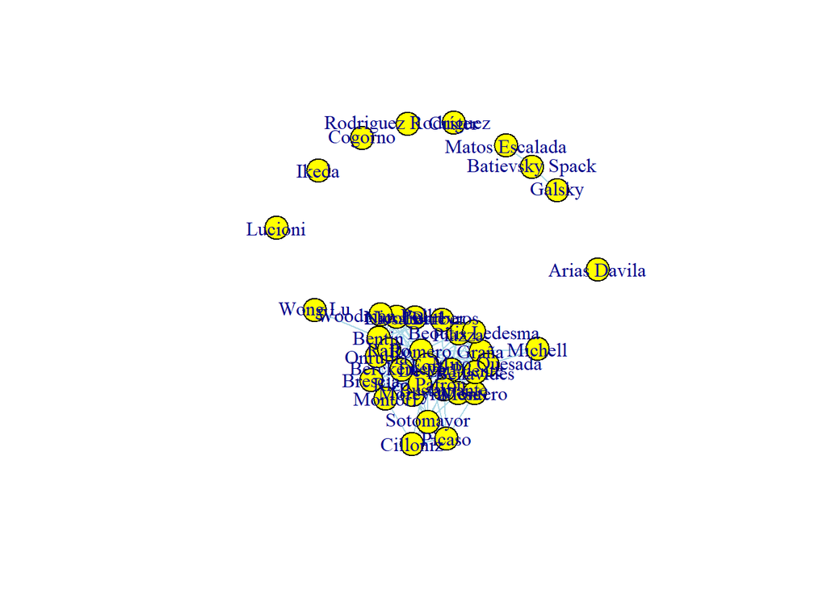

```r
plot.igraph(EliteNet,
            vertex.color = 'yellow',
            edge.color='lightblue')
```

Let’s add the attributes to the nodes:

```r
V(EliteNet)$Multinacional=FigueData$Multinacional
```

Updated nodes:

```r
V(EliteNet)$Multinacional
```

```
##  [1] 1 1 1 1 1 1 1 1 1 1 1 1 1 1 1 1 1 1 0 1 1 1 1 1 1 0 0 1 1 1 0 0 1 0 0 0 1
```

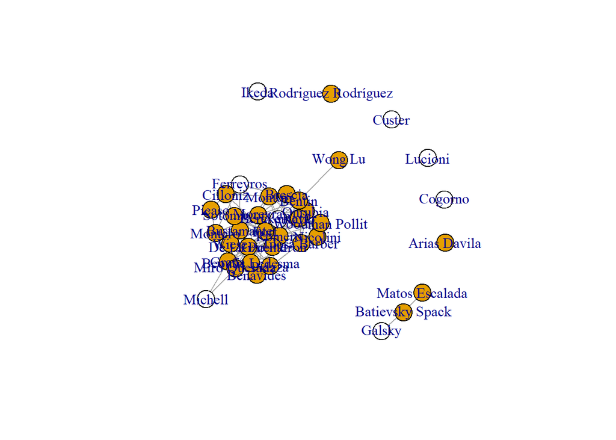

```r
# using node attributes
V(EliteNet)$color=V(EliteNet)$Multinacional

plot(EliteNet)
```

Trying a different layout:

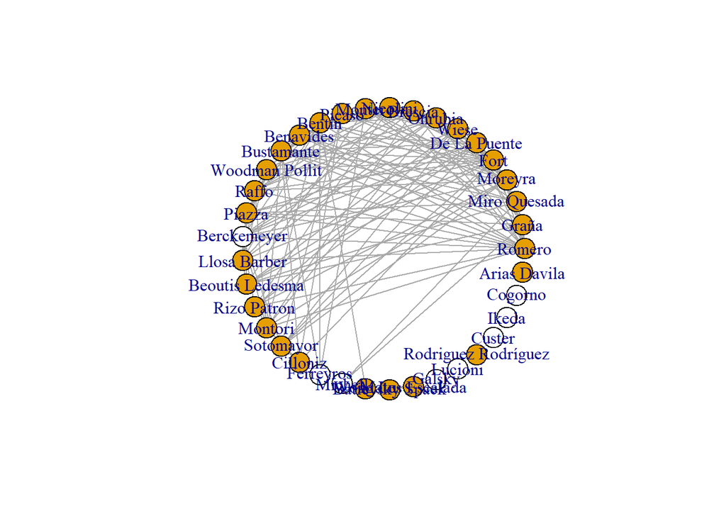

```r
plot(EliteNet, layout=layout.circle)
```

Let’s export this graph:

```r
where=file.path('data',"EliteNetR.graphml")
write_graph(EliteNet,where, "graphml")
```